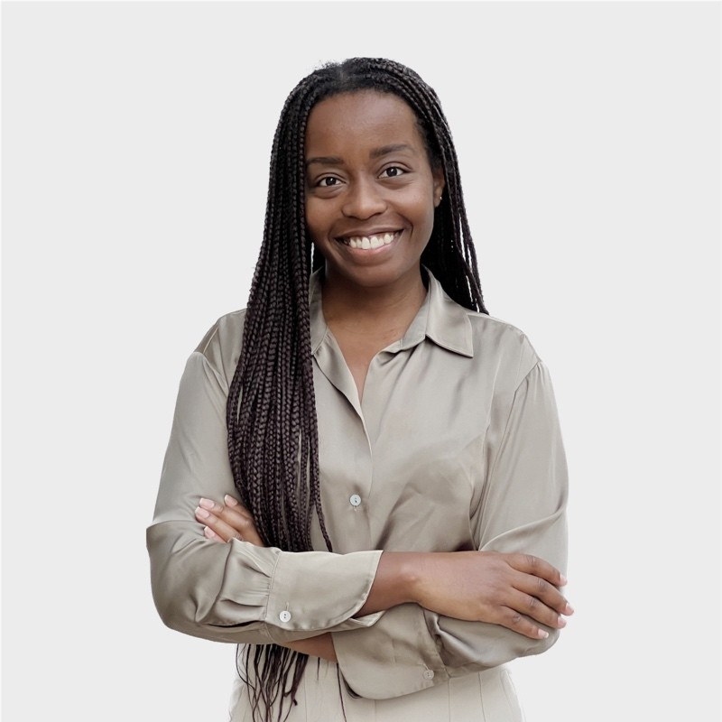

Bioinformática · Ciencia de Datos · Salud

# Melissa *Ndombasi* Bokuy

Apasionada por la ciencia y orientada a resultados. Combino biología, bioestadística y herramientas computacionales para resolver problemas complejos en salud.

Ver experiencia Contacto

Scroll

Sobre mí

## Ciencia con propósito

Profesional con base científica sólida y visión aplicada. Combino experiencia en el ámbito empresarial corporativo, análisis de datos y entornos de investigación biomédica.

Abierta a colaboraciones en proyectos multidisciplinares en los que pueda aportar mi experiencia y seguir aprendiendo, aplicando herramientas computacionales y métodos estadísticos al análisis de datos biológicos y de salud.

📍 La Coruña, España · 🌐 ES · EN · FR

Melissa NB

3 Titulaciones universitarias

6+ Años de experiencia empresarial

2 Publicaciones científicas

3 Idiomas

Trayectoria académica

## Formación

Actual

Máster en Bioinformática

Universidad Internacional de La Rioja

Completado

Máster en Bioestadística

Universidad Complutense de Madrid

Completado

Grado en Biología

Universidad Complutense de Madrid · Especialización en Biología Sanitaria

Competencias

## Habilidades

🧬

### Bioinformática

Biología computacional Datos biomédicos RNAseq Machine Learning

📊

### Análisis y Estadística

Preparación de datos Análisis estadísticos Modelos de regresión lineales y mixtos Visualización de datos

🔬

### Laboratorio

Inmunohistoquímica Microscopía confocal Modelos animales Marcaje celular

🌱

### Sostenibilidad corporativa

Estrategia Evaluación de estándares Coordinación de proyectos Colaboración multidisciplinar Comunicación

### Lenguajes de programación

R / RStudio

Python

Bash

### Idiomas

Español

Nativo

Inglés

C1

Francés

Intermedio

Trayectoria profesional

## Experiencia

ÁMBITO CORPORATIVO

### Técnico de Medioambiente

Inditex

- Desarrollo e implementación de estrategias
- Evaluación de certificaciones y trazabilidad de fibras
- Coordinación de proyectos
- Colaboración con stakeholders

Investigación

### Bioestadística

Facultad de Veterinaria · UCM

- Modelizacióne estadística
- Análisis cuantitativo de datos longitudinales
- Respresentación gráfica de datos
- Interpretación de resultados experimentales

Investigación

### Técnico de Laboratorio

Instituto Cajal · CSIC

- Inmunohistoquímica y marcaje celular
- Microscopía de fluorescencia y confocal
- Análisis de migración celular
- Estudio de desarrollo neural con modelos animales

Producción científica

## Publicaciones y proyectos

📄

[Immunization with recombinant rHc23 partially protects lambs against trickle infections by Haemonchus contortus](https://link.springer.com/article/10.1186/s12917-019-2084-5)

📄

[Modelo de simulación sobre políticas de vacunación VPH](https://docta.ucm.es/entities/publication/05fc67ae-ebb6-4844-8550-06b6ff39a408)

📄

Análisis expresión génica

📄

Análisis datos metagenómicos con QIIME2

📄

Análisis exploratorio y estadístico de expresión génica en R

📄

Ensayo sobre caso real: secuenciación genómica neonatal para la detección de enfermedades raras en el marco europeo

¿Hablamos?

## Contacto

Abierta a colaboraciones, proyectos de investigación y nuevas oportunidades.

📧 Melissanbokuy@gmail.com [LinkedIn](https://www.linkedin.com/in/melissa-ndombasi-bokuy-401a44176/)